# Albuquerque Home Prices (Data Wrangling and Regression)

Alejandro Aragon

11/22/2021

# Background:

A dataset of listing prices for dwellings (homes and apartments) for sale from [Zillow.com](http://www.zillow.com/homes/for_sale/Albuquerque-NM-87108/95303_rid/any_days/35.095087-106.52167835.035021-106.633258_rect/13_zm/0_mmm/) on Feb 26, 2016 at 1 PM for Albuquerque NM 87108 was composed by Professor Erik Erhardt in the University of New Mexico Statistics Department.

# Objective:

Develop a model to help understand which qualities that contribute to a **typical dwellings’ listing price**. Also, predict the listing prices of new listings.

```r
datFull <- read.csv(datapath, skip=2, stringsAsFactors = FALSE)[,-1]
str(datFull)
```

```
## 'data.frame':    143 obs. of  8 variables:
##  $ TypeSale  : chr  "HOUSE" "APARTMENT" "APARTMENT" "CONDO" ...
##  $ PriceList : int  186900 305000 244000 108000 64900 275000 133000 75000 149900 207000 ...
##  $ Beds      : int  3 1 1 3 2 3 2 2 3 3 ...
##  $ Baths     : num  2 1 1 2 1 3 1 2 2 2 ...
##  $ Size_sqft : int  1305 2523 2816 1137 1000 2022 1440 1207 1573 1394 ...
##  $ LotSize   : num  6969 6098 6098 NA NA ...
##  $ YearBuilt : int  1954 1948 1989 1996 1985 1952 1952 1965 1958 1952 ...
##  $ DaysListed: int  0 0 0 0 1 1 1 1 1 2 ...
```

```r
summary(datFull)
```

```
##    TypeSale           PriceList            Beds           Baths
##  Length:143         Min.   :  55000   Min.   :1.000   Min.   :1.000
##  Class :character   1st Qu.: 130000   1st Qu.:1.000   1st Qu.:1.000
##  Mode  :character   Median : 165000   Median :3.000   Median :1.000
##                     Mean   : 216716   Mean   :2.308   Mean   :1.585
##                     3rd Qu.: 234950   3rd Qu.:3.000   3rd Qu.:2.000
##                     Max.   :3110000   Max.   :5.000   Max.   :6.000
##                                                       NA's   :1
##    Size_sqft        LotSize         YearBuilt      DaysListed
##  Min.   :  610   Min.   :  3049   Min.   :1930   Min.   :   0.0
##  1st Qu.: 1238   1st Qu.:  6534   1st Qu.:1950   1st Qu.:  30.5
##  Median : 1700   Median :  6969   Median :1953   Median :  86.0
##  Mean   : 2194   Mean   : 13270   Mean   :1958   Mean   : 119.8
##  3rd Qu.: 2446   3rd Qu.:  8712   3rd Qu.:1962   3rd Qu.: 168.5
##  Max.   :33000   Max.   :609840   Max.   :2006   Max.   :1867.0
##                  NA's   :23       NA's   :4
```

# Data Cleaning and Wrangling

## Restrict data to “typical” dwellings

```r
datFull$TypeSale <- factor(datFull$TypeSale)
summary(datFull)
```

```
##               TypeSale    PriceList            Beds           Baths
##  APARTMENT        :41   Min.   :  55000   Min.   :1.000   Min.   :1.000
##  CONDO            : 5   1st Qu.: 130000   1st Qu.:1.000   1st Qu.:1.000
##  FOR SALE BY OWNER: 1   Median : 165000   Median :3.000   Median :1.000
##  FORECLOSURE      : 5   Mean   : 216716   Mean   :2.308   Mean   :1.585
##  HOUSE            :91   3rd Qu.: 234950   3rd Qu.:3.000   3rd Qu.:2.000
##                         Max.   :3110000   Max.   :5.000   Max.   :6.000
##                                                           NA's   :1
##    Size_sqft        LotSize         YearBuilt      DaysListed
##  Min.   :  610   Min.   :  3049   Min.   :1930   Min.   :   0.0
##  1st Qu.: 1238   1st Qu.:  6534   1st Qu.:1950   1st Qu.:  30.5
##  Median : 1700   Median :  6969   Median :1953   Median :  86.0
##  Mean   : 2194   Mean   : 13270   Mean   :1958   Mean   : 119.8
##  3rd Qu.: 2446   3rd Qu.:  8712   3rd Qu.:1962   3rd Qu.: 168.5
##  Max.   :33000   Max.   :609840   Max.   :2006   Max.   :1867.0
##                  NA's   :23       NA's   :4
```

**Step 1:**

Plotting the data to get a picture of and establish a “typical dwelling”.

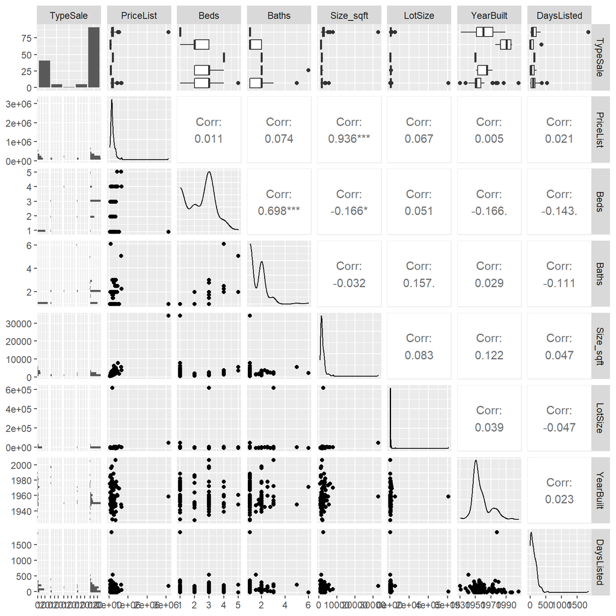

```r
library(GGally)
library(ggplot2)
p <- ggpairs(datFull
            , lower = list(continuous = "points")
            , upper = list(continuous = "cor")
            )
print(p)
```

```r
# Scaling year built has no impact on data and is purely for aesthetic reasons
datFull$YearBuilt_1900 <- datFull$YearBuilt - 1900
datFull$YearBuilt <- NULL
```

```r
# Targetting specific outlying observations for further inspection.
datFull[which(datFull$PriceList>1000000), ]
```

|  | TypeSale | PriceList | Beds | Baths | Size_sqft | LotSize | DaysListed | YearBuilt_1900 |
| --- | --- | --- | --- | --- | --- | --- | --- | --- |
| 120 | APARTMENT | 3110000 | 1 | 1 | 33000 | 56628 | 201 | 60 |

```r
datFull[which(datFull$LotSize>200000), ]
```

|  | TypeSale | PriceList | Beds | Baths | Size_sqft | LotSize | DaysListed | YearBuilt_1900 |
| --- | --- | --- | --- | --- | --- | --- | --- | --- |
| 31 | HOUSE | 175000 | 3 | 3 | 2314 | 609840 | 22 | 60 |

```r
datFull[which(datFull$DaysListed>750), ]
```

|  | TypeSale | PriceList | Beds | Baths | Size_sqft | LotSize | DaysListed | YearBuilt_1900 |
| --- | --- | --- | --- | --- | --- | --- | --- | --- |
| 143 | APARTMENT | 145000 | 1 | 1 | 2332 | 6534 | 1867 | 78 |

```r
datFull[which(datFull$Baths>4), ]
```

|  | TypeSale | PriceList | Beds | Baths | Size_sqft | LotSize | DaysListed | YearBuilt_1900 |
| --- | --- | --- | --- | --- | --- | --- | --- | --- |
| 18 | FORECLOSURE | 91200 | 4 | 6 | 2350 | 6534 | 8 | 72 |
| 130 | HOUSE | 650000 | 5 | 5 | 5573 | 13068 | 234 | 50 |

```r
# Assigning a working dataset.
datWork <- datFull
```

```r
datWork <- datFull
datWork <- datWork[-which(datWork$LotSize>12000), ]
datWork <- datWork[-which(datWork$DaysListed>365), ]
datWork <- datWork[-which(datWork$Baths>4), ]
```

```r
datWork <- datWork[-which(datWork$TypeSale == "CONDO")  ,]
datWork <- datWork[-which(datWork$TypeSale == "FOR SALE BY OWNER")  ,]
datWork <- datWork[-which(datWork$TypeSale == "FORECLOSURE")  ,]
datWork$TypeSale <- factor(datWork$TypeSale)
```

```r
summary(datWork)
```

```
##       TypeSale    PriceList           Beds          Baths         Size_sqft
##  APARTMENT:32   Min.   : 65000   Min.   :1.00   Min.   :1.000   Min.   : 783
##  HOUSE    :83   1st Qu.:137000   1st Qu.:1.00   1st Qu.:1.000   1st Qu.:1275
##                 Median :164950   Median :3.00   Median :1.000   Median :1700
##                 Mean   :186742   Mean   :2.33   Mean   :1.524   Mean   :1828
##                 3rd Qu.:225000   3rd Qu.:3.00   3rd Qu.:2.000   3rd Qu.:2360
##                 Max.   :450000   Max.   :5.00   Max.   :3.000   Max.   :3687
##                                                 NA's   :1
##     LotSize        DaysListed     YearBuilt_1900
##  Min.   : 3049   Min.   :  0.00   Min.   : 30.00
##  1st Qu.: 6534   1st Qu.: 29.50   1st Qu.: 50.00
##  Median : 6969   Median : 83.00   Median : 52.00
##  Mean   : 7139   Mean   : 96.01   Mean   : 55.89
##  3rd Qu.: 7405   3rd Qu.:148.00   3rd Qu.: 59.25
##  Max.   :10454   Max.   :341.00   Max.   :106.00
##  NA's   :18                       NA's   :3
```

**Visually reassessing the data**

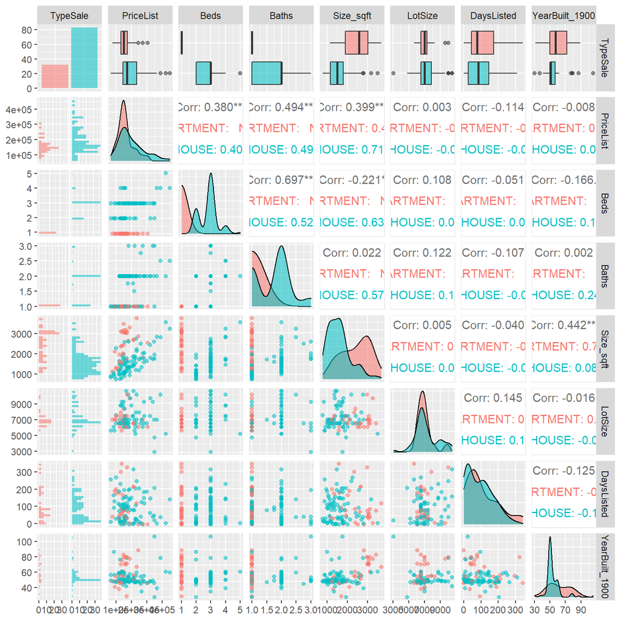

```r
library(GGally)
library(ggplot2)
p <- ggpairs(datWork
            , mapping = ggplot2::aes(colour = TypeSale, alpha = 0.5)
            , lower = list(continuous = "points")
            , upper = list(continuous = "cor")
            )
print(p)
```

**Response Centering**

```r
# Price in units of $1000
datWork$PriceListk <- datWork$PriceList / 1000
```

## Changes Made Because of Diagnostic Plots (Diagnostic Plot Analysis Section)

**Influential Observations**

Change will be made in susequent section for diagnostic plot demostration.

**Response Transformation**

```r
datWork$PriceListlg <- log10(datWork$PriceList)
```

**Predictor Transformation**

```r
datWork$Size_sqftlg <- log10(datWork$Size_sqft)
```

```r
datWork$LotSizelg <- log10(datWork$LotSize)
```

**YearBuilt Distribution**

Note that this change will change the look of the original diagnostic plots.

```r
datWork <- datWork[-which(datWork$YearBuilt_1900>=100), ]
```

# Subset data for model building and prediction

Creating a subset of the data for building the model, and another subset for prediction later on.

```r
# remove observations with NAs
datWork <- na.omit(datWork)

# the data subset we will use to build our model
dat.sub <- subset(datWork, DaysListed > 0)

# the data subset we will predict from our model
dat.pred <- subset(datWork, DaysListed == 0)
```

```r
# the prices we hope to predict well from our model
dat.pred$PriceListlg_true <- dat.pred$PriceListlg
# set them to NA to predict them later
dat.pred$PriceListlg <- NA
```

# Modeling

## Initial (Full) Model

A two-way interaction model will be fit to the full dataset without transformations

```r
lm.full <- lm(PriceListk ~ (TypeSale + Beds + Size_sqft + DaysListed + YearBuilt_1900 + LotSize)^2, data = dat.sub)
#lm.full <- lm(PriceList ~ (Beds + Baths + Size.sqftlg + LotSizelg + DaysListed + YearBuilt_1900)^2, data = dat.abq.sv)
library(car)
try(Anova(lm.full, type=3))
```

```
## Error in Anova.III.lm(mod, error, singular.ok = singular.ok, ...) :
##   there are aliased coefficients in the model
```

```r
## Note that this doesn't work because APARTMENTs only have 1 bed and 1 bath.
## There isn't a second level of bed or bath to estimate the interaction.
## Therefore, remove those two terms
lm.full <- update(lm.full, . ~ . - TypeSale:Beds - TypeSale:Baths)
library(car)
try(Anova(lm.full, type=3))
```

|  | Sum Sq | Df | F value | Pr(>F) |
| --- | --- | --- | --- | --- |
| (Intercept) | 18329.0092 | 1 | 8.10307170 | 0.005815103 |
| TypeSale | 1630.5150 | 1 | 0.72083439 | 0.398806394 |
| Beds | 4089.9892 | 1 | 1.80814333 | 0.183134832 |
| Size_sqft | 1018.7525 | 1 | 0.45038027 | 0.504394879 |
| DaysListed | 2040.4568 | 1 | 0.90206557 | 0.345543356 |
| YearBuilt_1900 | 1770.5748 | 1 | 0.78275341 | 0.379373050 |
| LotSize | 8724.7359 | 1 | 3.85711850 | 0.053565332 |
| TypeSale:Size_sqft | 118.8416 | 1 | 0.05253867 | 0.819381302 |
| TypeSale:DaysListed | 303.8925 | 1 | 0.13434785 | 0.715087536 |
| TypeSale:YearBuilt_1900 | 15456.7726 | 1 | 6.83328459 | 0.010976896 |

[output cut: 12 more lines]

## Residual Analysis and Diagnostic Plots

```r
lm.diag.plots <- function(fit, rc.mfrow=NA, which.plot=c(1,4,6), sw.order.of.data = FALSE) {
  ## lm.diag.plots() is a general function for plotting residual diagnostics for an lm() object
  ## Arguments:
  # fit          linear model object returned by lm()
  # rc.mfrow     number of rows and columns for the graphic plot, e.g., c(2,3)
  # which.plot   default plot numbers for lm()
  # outliers     number to identify in plots from lm() and qqPlot()
  # sw.order.of.data T/F for whether to show residuals by order of data

  # variable names
  var.names <- names(fit$model)[-1]
  # display settings
  if (is.na(rc.mfrow[1])) {
    rc.mfrow <- c(ceiling((length(var.names) + 3 + length(which.plot) + sw.order.of.data) / 3), 3)
  }
  op <- par(no.readonly = TRUE) # the whole list of settable par
  par(mfrow = rc.mfrow)

  # default: Fitted, Cook's distance (with cutoff), and Leverage (with cutoffs)
  for(i.plot in which.plot) {
    plot(fit, which = i.plot)
    if (i.plot == 4) {
      Di.large <- 4 / (dim(fit$model)[1] - dim(fit$model)[2] - 1)
      abline(h = Di.large, col = "blue", lty = 3)  # horizontal line
    }
    if (i.plot == 6) {
      lev.large <- c(2, 3) * dim(fit$model)[2] / dim(fit$model)[1]
      abline(v = lev.large[1], col = "blue", lty = 3)  # horizontal line
      abline(v = lev.large[2], col = "blue", lty = 2)  # horizontal line
    }
  }

  # Evaluate homoscedasticity
  library(car)
  # non-constant error variance test
  print(ncvTest(fit))
  # plot studentized residuals vs. fitted values
  try(spreadLevelPlot(fit, sub = "(Homoscedasticity)"))

  # Evaluate Collinearity
  library(car)
  vif.val <- vif(fit) # variance inflation factors
  dotchart(vif.val, main = "Collinearity", xlab = "Variance Inflation Factor (VIF)", sub = "Not as useful with interactions")
  abline(v = 2^2, col = "blue", lty = 2)  # vertical line

  # Normal quantile plot (QQ-plot)
  library(car)
  qqPlot(fit$residuals, las = 1, main="QQ Plot", ylab = "Residuals")

  # Box-Cox transformation suggestion
  # only if all values are positive
  if(min(fit$model[,1] > 0)){
    library(car)
    boxCox(lm.full, lambda = seq(-3,3,length=101), main = "Box-Cox power transformation")
  }

  # residuals vs order of data
  if(sw.order.of.data) {
    # order of data (not always interesting)
    plot(fit$residuals, main="Residuals vs Order of data", ylab = "Residuals")
    abline(h = 0, col = "gray75", lty = 3)  # horizontal line at zero
  }

  # residuals plotted vs each main effect
  for(i.plot in 1:length(var.names)) {
    m.lab <- paste("Residuals vs.", var.names[i.plot])
    plot(fit$model[,var.names[i.plot]], fit$residuals, main=m.lab, ylab = "Residuals", xlab = var.names[i.plot])
    abline(h = 0, col = "gray75", lty = 3)  # horizontal line at zero
  }

  par(op) # reset plotting options

  ## Useful list of diags: http://www.statmethods.net/stats/rdiagnostics.html
} # end of reg.diag.plots()
```

```
FALSE Non-constant Variance Score Test
FALSE Variance formula: ~ fitted.values
FALSE Chisquare = 0.02787496, Df = 1, p = 0.8674
```

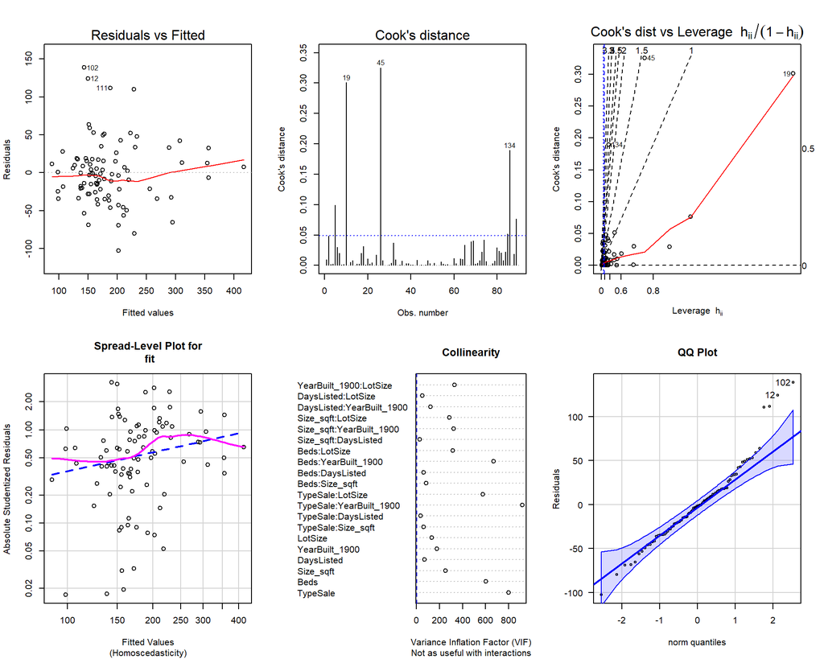

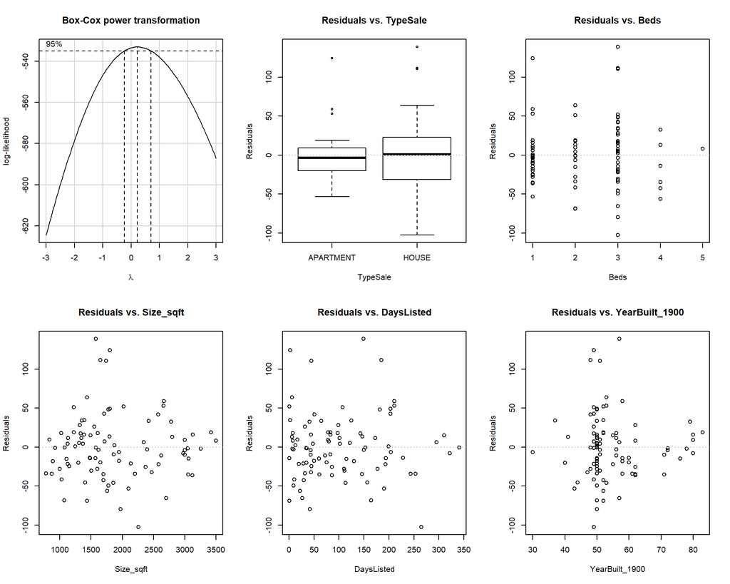

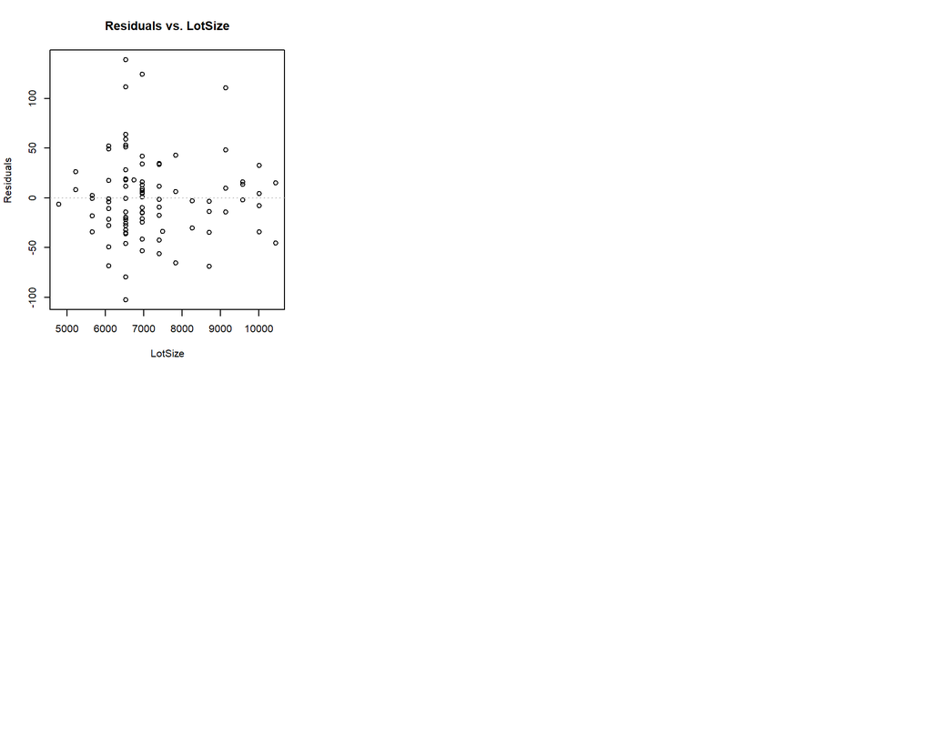

```r
lm.diag.plots(lm.full, rc.mfrow = c(2,3))
```

### Diagnostic Plot Analyses

These problems will be addressed in the **Data Cleaning and Wrangling** section.

## Second Model (After Changes)

Linear model after transformations noted above

```r
## Remove influential observations
## Observations 45 and 137 added after second model
dat.sub <- dat.sub[-which(row.names(dat.sub) %in% c(32, 19, 45, 137)),]
```

```r
lm.trans.dat <- lm(PriceListlg ~ (TypeSale + Beds + Size_sqftlg + DaysListed + YearBuilt_1900 + LotSizelg)^2, data = dat.sub)
#lm.full <- lm(PriceList ~ (Beds + Baths + Size.sqftlg + LotSizelg + DaysListed + YearBuilt_1900)^2, data = dat.abq.sv)
library(car)
try(Anova(lm.trans.dat, type=3))
```

```
## Error in Anova.III.lm(mod, error, singular.ok = singular.ok, ...) :
##   there are aliased coefficients in the model
```

```r
lm.trans.dat <- update(lm.trans.dat, . ~ . - TypeSale:Beds - TypeSale:Baths)
library(car)
try(Anova(lm.trans.dat, type=3))
```

|  | Sum Sq | Df | F value | Pr(>F) |
| --- | --- | --- | --- | --- |
| (Intercept) | 1.532844e-02 | 1 | 1.322650311 | 0.25426712 |
| TypeSale | 3.576876e-02 | 1 | 3.086390925 | 0.08358783 |
| Beds | 1.134485e-02 | 1 | 0.978917013 | 0.32607981 |
| Size_sqftlg | 6.763637e-04 | 1 | 0.058361613 | 0.80985348 |
| DaysListed | 1.066749e-02 | 1 | 0.920469380 | 0.34085335 |
| YearBuilt_1900 | 3.456753e-02 | 1 | 2.982739691 | 0.08883441 |
| LotSizelg | 1.516672e-02 | 1 | 1.308696083 | 0.25676304 |
| TypeSale:Size_sqftlg | 2.128156e-02 | 1 | 1.836328857 | 0.18000183 |
| TypeSale:DaysListed | 8.370867e-05 | 1 | 0.007222997 | 0.93252804 |
| TypeSale:YearBuilt_1900 | 1.404040e-05 | 1 | 0.001211509 | 0.97233891 |

[output cut: 12 more lines]

```
FALSE Non-constant Variance Score Test
FALSE Variance formula: ~ fitted.values
FALSE Chisquare = 0.09994103, Df = 1, p = 0.7519
```

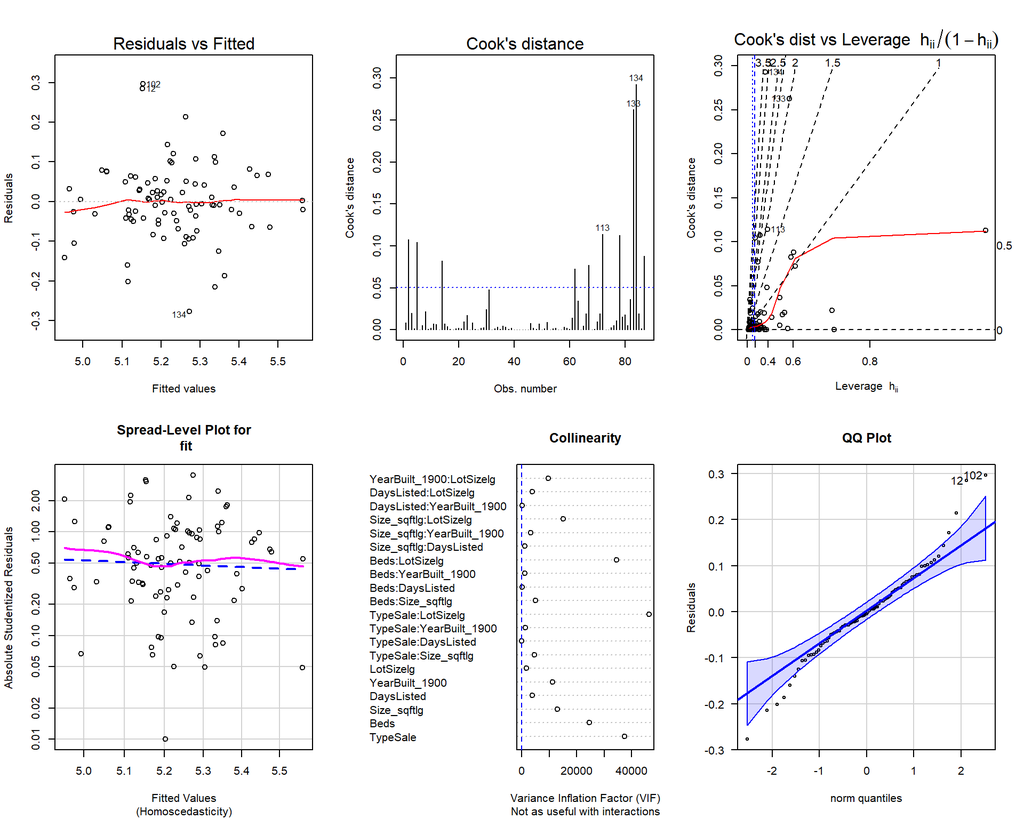

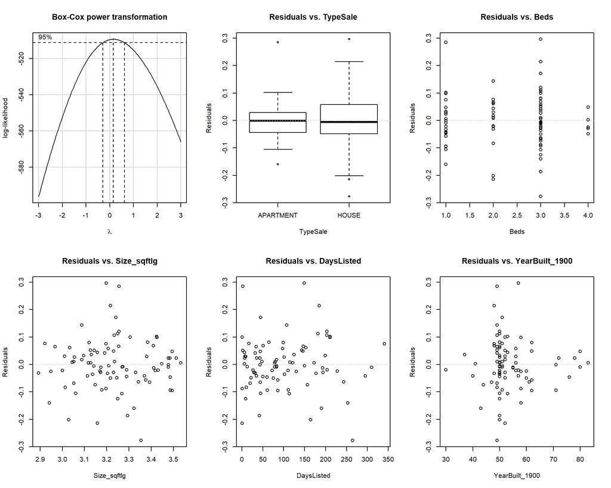

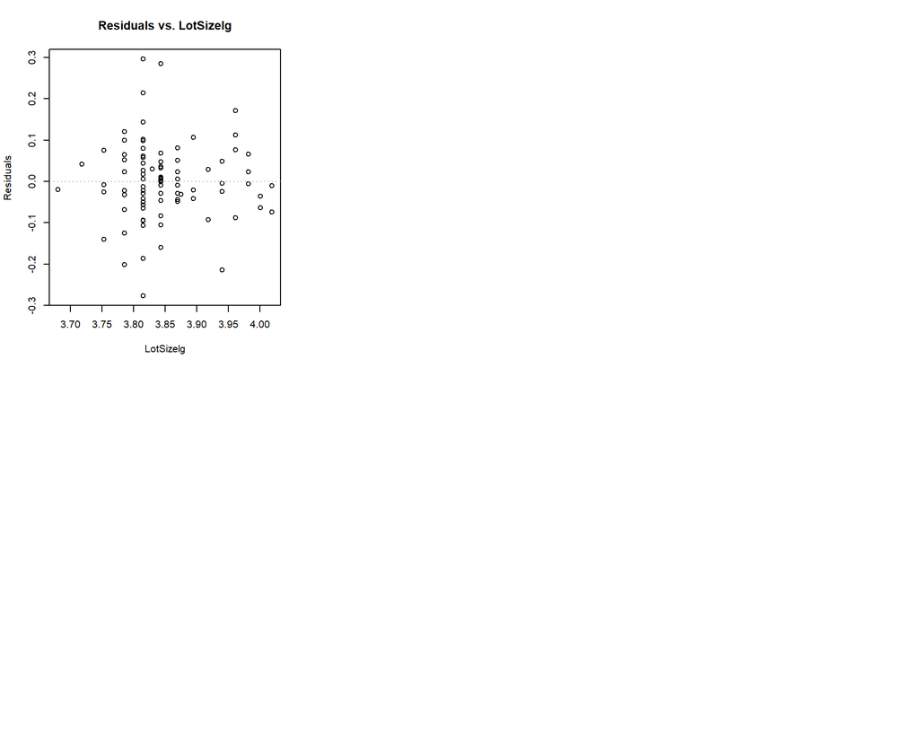

```r
lm.diag.plots(lm.trans.dat, rc.mfrow = c(2,3))
```

Scatterplot of the model-building subset.

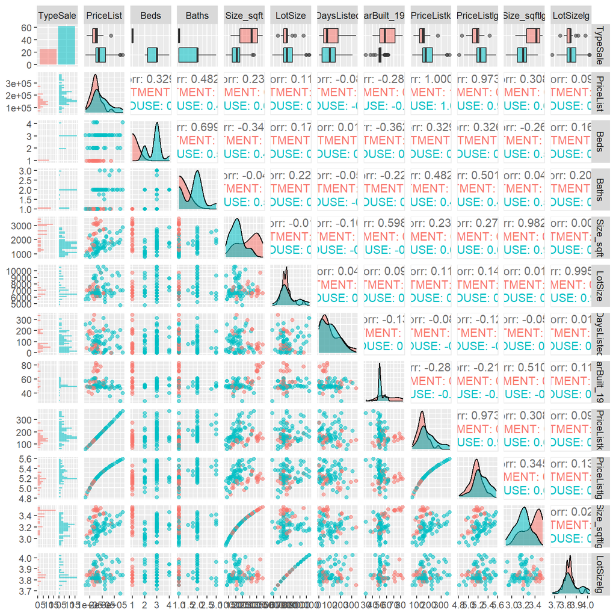

```r
library(GGally)
library(ggplot2)
p <- ggpairs(dat.sub
            , mapping = ggplot2::aes(colour = TypeSale, alpha = 0.5)
            , lower = list(continuous = "points")
            , upper = list(continuous = "cor")
            )
print(p)
```

## Model Selection (Check Model Assumptions)

Using `step(..., direction="both")` with the BIC criterion, perform model selection.

```
FALSE Non-constant Variance Score Test
FALSE Variance formula: ~ fitted.values
FALSE Chisquare = 1.840347, Df = 1, p = 0.17491
```

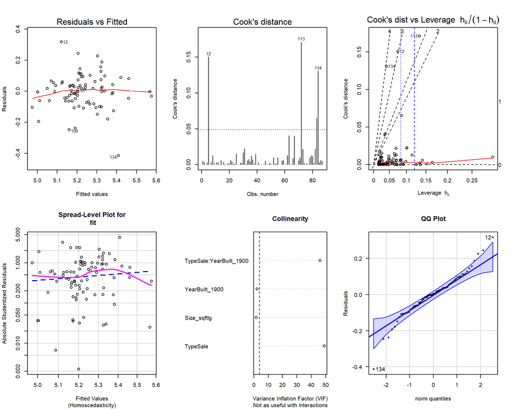

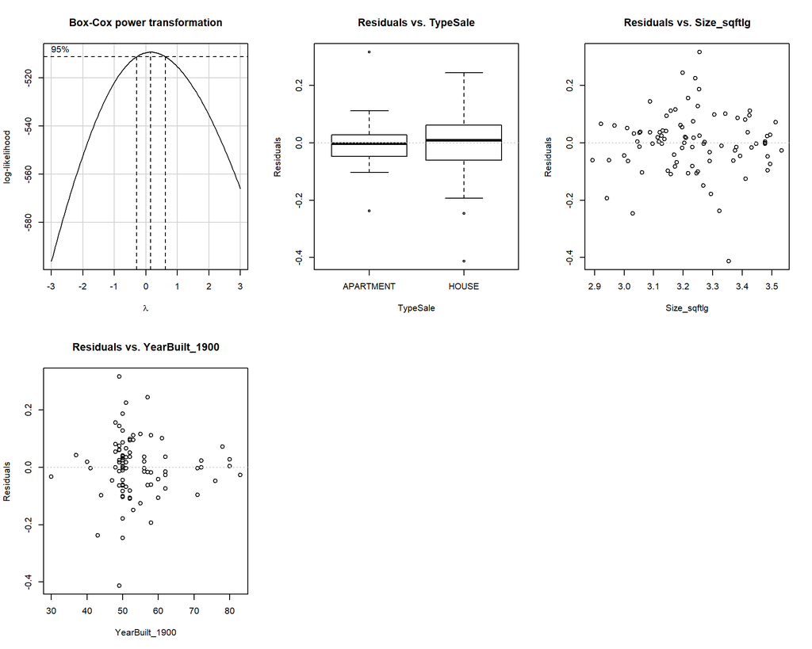

```r
lm.red.BIC <- step(lm.trans.dat, direction="both", test="F", trace = 0
                         , k=log(nrow(dat.sub)))
lm.final <- lm.red.BIC

lm.diag.plots(lm.final, rc.mfrow = c(2,3))
```

Model assumptions appear to be reasonably met.

**Final Model**

```r
summary(lm.final)
```

```
##
## Call:
## lm(formula = PriceListlg ~ TypeSale + Size_sqftlg + YearBuilt_1900 +
##     TypeSale:YearBuilt_1900, data = dat.sub)
##
## Residuals:
##      Min       1Q   Median       3Q      Max
## -0.41375 -0.06065  0.00322  0.05319  0.31661
##
## Coefficients:
##                               Estimate Std. Error t value Pr(>|t|)
## (Intercept)                   2.912891   0.292601   9.955 9.15e-16 ***
## TypeSaleHOUSE                 0.591045   0.180331   3.278  0.00154 **
## Size_sqftlg                   0.732315   0.097375   7.521 6.17e-11 ***
## YearBuilt_1900               -0.003584   0.001952  -1.836  0.06995 .
## TypeSaleHOUSE:YearBuilt_1900 -0.007651   0.003358  -2.279  0.02529 *
## ---
## Signif. codes:  0 '***' 0.001 '**' 0.01 '*' 0.05 '.' 0.1 ' ' 1
##
## Residual standard error: 0.1086 on 82 degrees of freedom
## Multiple R-squared:  0.5481, Adjusted R-squared:  0.526
## F-statistic: 24.86 on 4 and 82 DF,  p-value: 1.695e-13
```

### Interpretation of Model Coeffcients

The intercept means that the “starting price” to purchase a dwelling is 812.83 (10^2.91). If the this is a house being sold this listing price increases to $3162.28 (10^(2.91 + .59)). For every unit increase in square footage the listing price increases by $5.37. Oddly for every unit increase in year built the price *decreases* by $1.01 (10 ^ .003584)

## Plot Final Model

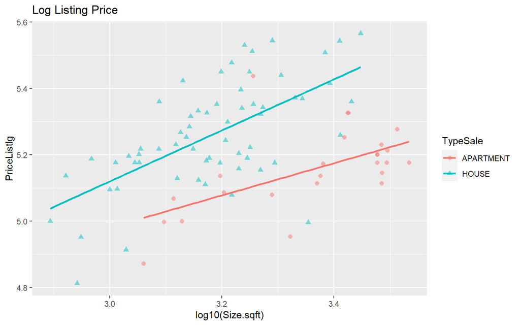

# Prediction

```r
# predict new observations, convert to data frame
lm.pred <- as.data.frame(predict(lm.final, newdata = dat.pred, interval = "prediction"))
# add column of actual list prices
lm.pred$PriceListlg <- dat.pred$PriceListlg_true


10^lm.pred
```

|  | fit | lwr | upr | PriceListlg |
| --- | --- | --- | --- | --- |
| 1 | 150950.2 | 91258.21 | 249686.6 | 186900 |
| 2 | 170652.7 | 101224.44 | 287700.7 | 305000 |
| 3 | 131854.5 | 75365.74 | 230683.2 | 244000 |

```r
# attributes of the three predicted observations
dat.pred
```

|  | TypeSale | PriceList | Beds | Baths | Size_sqft | LotSize | DaysListed | YearBuilt_1900 | PriceListk | PriceListlg | Size_sqftlg | LotSizelg | PriceListlg_true |
| --- | --- | --- | --- | --- | --- | --- | --- | --- | --- | --- | --- | --- | --- |
| 1 | HOUSE | 186900 | 3 | 2 | 1305 | 6969 | 0 | 54 | 186.9 | NA | 3.115611 | 3.843170 | 5.271609 |
| 2 | APARTMENT | 305000 | 1 | 1 | 2523 | 6098 | 0 | 48 | 305.0 | NA | 3.401917 | 3.785187 | 5.484300 |
| 3 | APARTMENT | 244000 | 1 | 1 | 2816 | 6098 | 0 | 89 | 244.0 | NA | 3.449633 | 3.785187 | 5.387390 |

With the three observations held out to predict against only one fell within the prediction interval.

# Conclusion

This model isn’t expected to predict the price of a dwelling very well, because the final model Adjusted $R^2$ accounts for only 53% of the variability in the data. The poor predictive power of the model is also shown by the prediction interval being so wide. Problems with this model stems from the lack of observations and not enough observations in other `SaleType` factor levels which could’ve given more insight in the relation of the listing price. Since this is “real world” data the lack of predictive power and low $R^2$ is not surprising as data could always be better when not controlled in a lab setting. What could possibly be looked into is the ability to categorize housing and apartments, the very slight grouping between the two can be seen in the Log Listing Price plot, but this would not be a very helpful model unless for some reason the dwelling type is not listed in the dataset.